**Why**: Installing and loading libraries upfront ensures that all required tools are available for the analysis. Setting conflict preferences helps avoid ambiguity when multiple packages have functions with the same name.

# Step 1: Collect Data

We will start by loading the data for Q1 2019 and Q1 2020 from the provided CSV files.

`# Load CSV Files q1_2019 <- read_csv("Divvy_Trips_2019_Q1.csv") q1_2020 <- read_csv("Divvy_Trips_2020_Q1.csv")`

**Why**: Loading the data is the first step in performing data analysis. By loading it into R, we can clean, transform, and analyze it.

# Step 2: Wrangle Data and Combine into a Single File

To ensure consistency in analysis, the columns of both datasets need to be standardized. We also need to make sure that the data types are compatible before combining the dataframes.

First, let’s inspect the column names in each dataset.

`# Check the column names to determine renaming needs colnames(q1_2019) colnames(q1_2020)`

Next, we rename the columns in `q1_2019` to match those in `q1_2020`.

`` # Rename columns in `q1_2019` to match `q1_2020` q1_2019 <- rename(q1_2019, ride_id = trip_id, rideable_type = bikeid, started_at = start_time, ended_at = end_time, start_station_name = from_station_name, start_station_id = from_station_id, end_station_name = to_station_name, end_station_id = to_station_id, member_casual = usertype) ``

Now, we ensure consistent data types across both datasets to facilitate merging.

`# Ensure consistent data types for merging q1_2019 <- mutate(q1_2019, ride_id = as.character(ride_id), rideable_type = as.character(rideable_type)) q1_2020 <- mutate(q1_2020, ride_id = as.character(ride_id), rideable_type = as.character(rideable_type))`

Finally, we combine both dataframes into a single dataframe called `all_trips`.

`# Combine Dataframes all_trips <- bind_rows(q1_2019, q1_2020)`

**Why**: Renaming columns ensures a seamless merge of the datasets. Ensuring data types are consistent helps avoid type mismatch errors during binding. Combining datasets allows us to perform a unified analysis across multiple time periods.

# Step 3: Clean Data and Add Features

To make the dataset more manageable and ensure consistency, we need to clean the data, standardize categorical variables, and add new features.

`` # Standardize `member_casual` column values to ensure consistency all_trips <- all_trips %>% mutate(member_casual = recode(member_casual, "Subscriber" = "member", "Customer" = "casual")) # Remove unnecessary columns to simplify the dataset all_trips <- all_trips %>% select(-c(start_lat, start_lng, end_lat, end_lng, birthyear, gender, tripduration)) # Add date-based features for analysis all_trips <- all_trips %>% mutate(date = as.Date(started_at), month = format(date, "%m"), day = format(date, "%d"), year = format(date, "%Y"), day_of_week = format(date, "%A")) # Calculate ride length in minutes all_trips$ride_length <- as.numeric(difftime(all_trips$ended_at, all_trips$started_at, units = "mins")) # Remove rows with invalid ride length or test rides all_trips_v2 <- all_trips %>% filter(start_station_name != "HQ QR" & ride_length > 0) ``

**Why**: Cleaning the data and standardizing values ensures consistency, which is critical for analysis. Adding date features allows us to perform time-based analysis, and filtering out invalid data ensures we only analyze relevant entries.

# Step 4: Analyze Data

Now that we have a clean dataset, we can perform some initial analysis to understand the data.

**Why**: Performing descriptive analysis helps us identify patterns and trends in the data, such as ride duration differences between casual and member riders.

# Step 5: Visualize Data

To better understand the data and effectively communicate our findings, we will create some visualizations.

`# Visualize the number of rides by rider type and weekday all_trips_v2 %>% mutate(weekday = wday(started_at, label = TRUE)) %>% group_by(member_casual, weekday) %>% summarise(number_of_rides = n(), average_duration = mean(ride_length)) %>% arrange(member_casual, weekday) %>% ggplot(aes(x = weekday, y = number_of_rides, fill = member_casual)) + geom_col(position = "dodge") + labs(title = "Number of Rides by Rider Type and Weekday", x = "Weekday", y = "Number of Rides")`

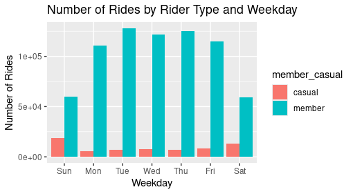

`# Visualize the average ride duration by rider type and weekday all_trips_v2 %>% mutate(weekday = wday(started_at, label = TRUE)) %>% group_by(member_casual, weekday) %>% summarise(number_of_rides = n(), average_duration = mean(ride_length)) %>% arrange(member_casual, weekday) %>% ggplot(aes(x = weekday, y = average_duration, fill = member_casual)) + geom_col(position = "dodge") + labs(title = "Average Ride Duration by Rider Type and Weekday", x = "Weekday", y = "Average Duration (mins)")`

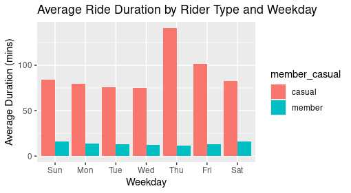

**Why**: Visualizing data makes it easier to identify trends and communicate findings effectively to stakeholders.

# Step 6: Export Data

Finally, we export some of the aggregated data for external analysis or reporting.

`# Export aggregated ride length data for external analysis counts <- aggregate(ride_length ~ member_casual + day_of_week, data = all_trips_v2, FUN = mean) write.csv(counts, file = "avg_ride_length.csv")`

**Why**: Exporting data enables us to use it in presentations, dashboards, or for further analysis using other tools.

# Conclusion

This report provides an analysis of Cyclistic’s bike-share program, focusing on understanding usage patterns between casual and annual members. The goal is to help inform marketing strategies to convert casual riders into annual members.